# Modelling interactions and contrasts

# Modelling interactions and contrasts

Spider leg hair pulling / pushing friction dataset (Wolff, Gorb (2013))

```r
library(tidyverse)
library(downloader)
library(rafalib)
```

```r
url <- "https://raw.githubusercontent.com/genomicsclass/dagdata/master/inst/extdata/spider_wolff_gorb_2013.csv"
filename <- "spider_wolff_gorb_2013.csv"
if (!file.exists(filename)) download(url, filename)
spider <- read.csv(filename, skip=1)
```

Data describes frictional coefficient for pulling / pushing, for each spider leg pair (L1, L2, L3, L4).

```r
head(spider)
```

```
  leg type friction
1  L1 pull     0.90
2  L1 pull     0.91
3  L1 pull     0.86
4  L1 pull     0.85
5  L1 pull     0.80
6  L1 pull     0.87
```

# Experiment overview

Spiders have 4 leg pairs. Each leg pair is labelled L1 - L4. *Cupiennius. salei* spider tarsas and claw tuft were collected, air dried, then performed pulling / pushing simulations. Friction on each leg pair samples were measured via force transducer.

Friction coefficients were recorded for each leg pair during pulling, and pushing movement.

The overview of boxplot data depicts higher friction coefficients in pulling movements. Early interpretations: leg pair L4 has a notably wider range of friction coefficients for pushing movements, suggesting pushing movement (moving away/backwards/rotate) is predominantly performed with the back leg pair (L4).

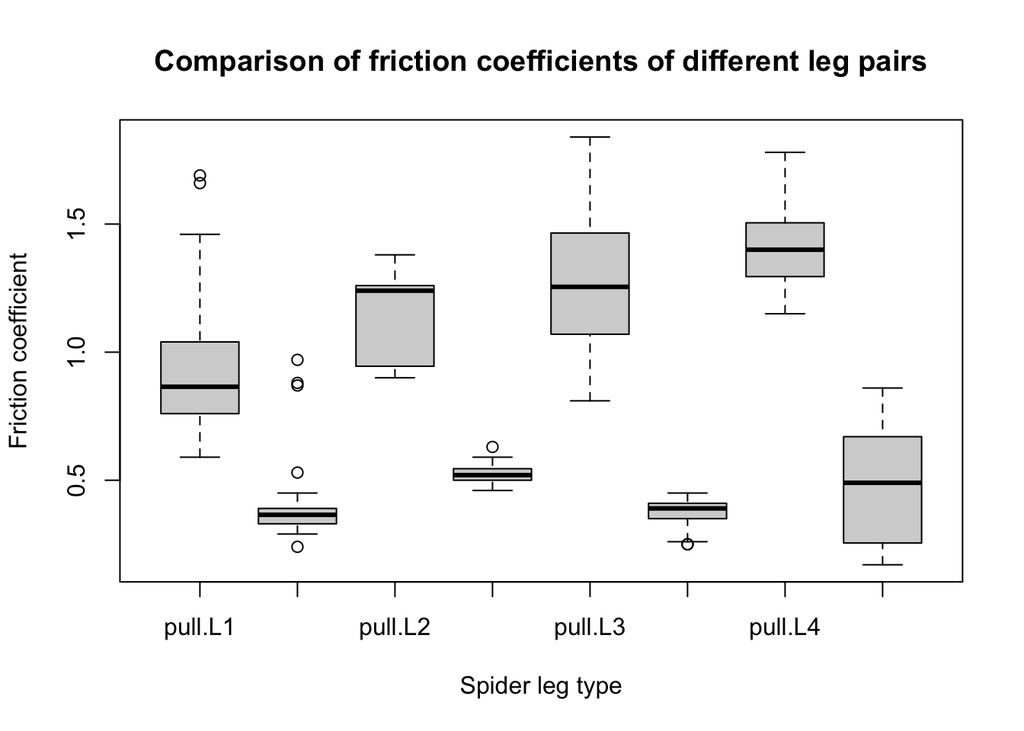

```r
boxplot(spider$friction ~ spider$type*spider$leg, main = "Comparison of friction coefficients of different leg pairs", ylab = "Friction coefficient", xlab = "Spider leg type")
```

```r
spider.sub <- spider[spider$leg == "L1",] # filter L1 leg pair subset (rows, keep matrix) [r,] from spider dataset
X <- model.matrix(~type, data = spider.sub) # filter L1 pairs by pull / push types
colnames(X)
```

```
[1] "(Intercept)" "typepush"
```

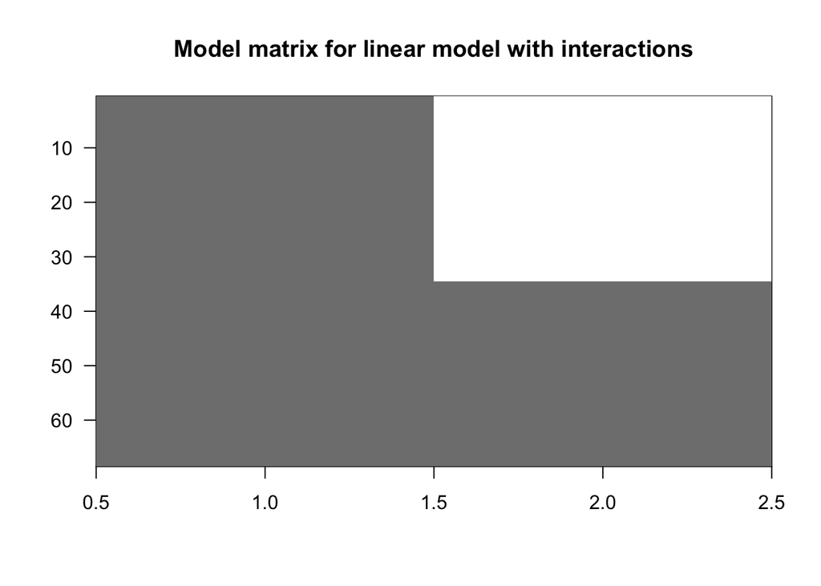

```r
imagemat(X, main = "Model matrix for linear model with interactions")
```

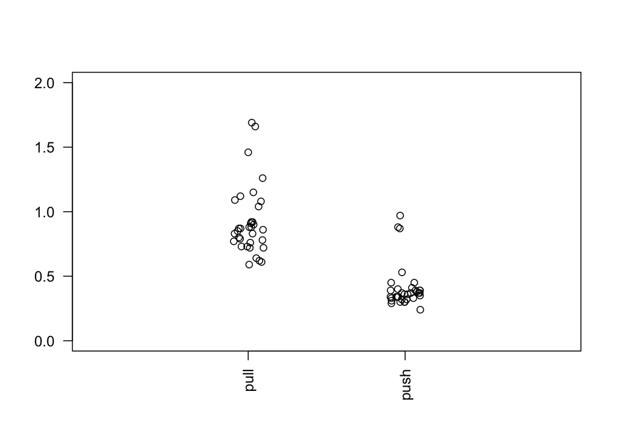

```r
stripchart(split(spider.sub$friction, spider.sub$type), # plot friction coefficients for L1
           vertical = TRUE, pch = 1, method = "jitter", las = 2,
           xlim = c(0,3), ylim = c(0,2))
```

Above dataset was modelled with one variable for demonstration of interactions. (Linear models are typically performed with >2 variables):

type = pull / push

leg = L1-L4

Generate intercept (typepull L1), typepush (for all leg pairs):

```r
# X <- model.matrix(~type, data = spider) # filters into pull (intercept) and push types for all leg types
X <- model.matrix(~type + leg, data = spider)  # filters
head(X)
```

```
  (Intercept) typepush legL2 legL3 legL4
1           1        0     0     0     0
2           1        0     0     0     0
3           1        0     0     0     0
4           1        0     0     0     0
5           1        0     0     0     0
6           1        0     0     0     0
```

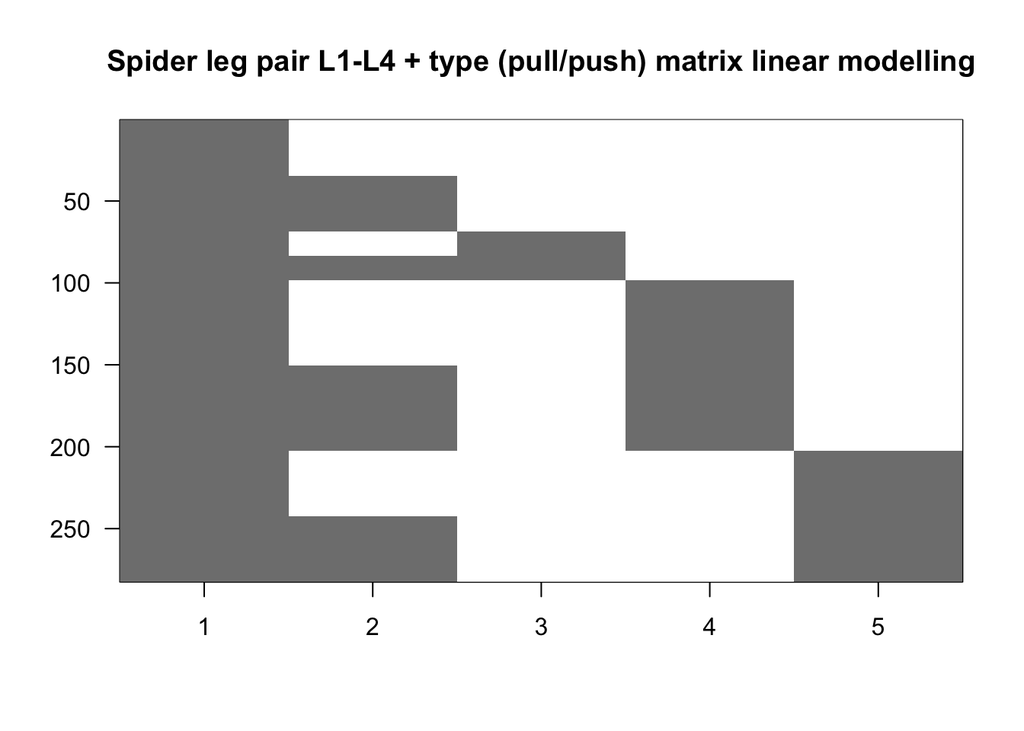

```r
imagemat(X, main = "Spider leg pair L1-L4 + type (pull/push) matrix linear modelling")
```

x: 1 = typepull (L1); 2 = typepush (L1); 3 = L2; 4 = L3; 5 = L4

grey = 1; white = 0

col3 (L2 leg pair) has a considerably lower range of values than col4 (L3), suggesting fewer range of friction coefficient data for L2 than the other leg pairs.

```r
sum(spider == "L2")
```

```
[1] 30
```

```r
sum(spider == "L3")
```

```
[1] 104
```

```r
sum(spider == "L4")
```

```
[1] 80
```

Fit the linear model: friction against leg pair + type (pull/push). Use + to simulate offset/additive effect.

```r
head(spider)
```

```
  leg type friction
1  L1 pull     0.90
2  L1 pull     0.91
3  L1 pull     0.86
4  L1 pull     0.85
5  L1 pull     0.80
6  L1 pull     0.87
```

```r
fit2 <- lm(friction ~ leg + type, data = spider)
summary(fit2)
```

```
Call:
lm(formula = friction ~ leg + type, data = spider)

Residuals:
     Min       1Q   Median       3Q      Max
-0.46392 -0.13441 -0.00525  0.10547  0.69509

Coefficients:
            Estimate Std. Error t value Pr(>|t|)
(Intercept)  1.05392    0.02816  37.426  < 2e-16 ***
legL2        0.17192    0.04569   3.763 0.000205 ***
legL3        0.16049    0.03251   4.937 1.37e-06 ***
legL4        0.28134    0.03438   8.183 1.01e-14 ***
typepush    -0.77901    0.02482 -31.380  < 2e-16 ***
---
Signif. codes:  0 '***' 0.001 '**' 0.01 '*' 0.05 '.' 0.1 ' ' 1

Residual standard error: 0.2084 on 277 degrees of freedom
Multiple R-squared:  0.7916,    Adjusted R-squared:  0.7886
F-statistic:   263 on 4 and 277 DF,  p-value: < 2.2e-16
```

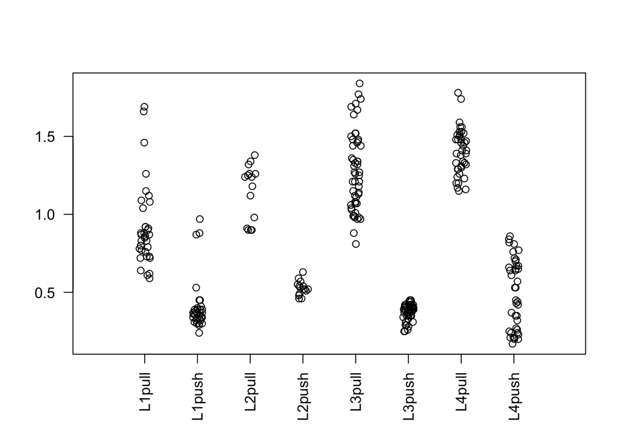

```r
spider$group <- factor(paste0(spider$leg, spider$type))
stripchart(split(spider$friction, spider$group), vertical = TRUE, method = "jitter", pch = 1, las = 2, xlim = c(0,9))
```

```r
# pch = dot shape, las = x-axis value text orientation
```

Friction coefficient of each LegPair/Type is not equivalent to the mean - the above demonstration assumes equal variance across all leg pull/push groups.

Where we cannot assume equal variance, data must be transformed e.g. via log or sqrt, to reflect the variance, then use lm().

Or, use Welch’s t-test or Wilcoxon rank sum for unequal variance data, without needing to transform values.

```r
coef <- coef(fit2)
coef
```

```
(Intercept)       legL2       legL3       legL4    typepush
  1.0539153   0.1719216   0.1604921   0.2813382  -0.7790071
```

The above coefficients compare each group to the intercept (L1 pull).

# Interactions

The above compares coefficient for each leg pair against the baseline reference (L1)). The above demonstration uses coefficient leg + type. The + acts as a fixed offset, to add a universal typepush coefficient, to add onto each leg pull coefficient.

Leg * type describes the interaction between each group: the effect of typepush differs for each leg pair. This introduces new typepush coefficients for L2, L3, L4, instead of using L1 typepush as a universal/fixed offset for leg pushing.

```r
X <- model.matrix(~ type*leg, data = spider)
colnames(X)
```

```
[1] "(Intercept)"    "typepush"       "legL2"          "legL3"
[5] "legL4"          "typepush:legL2" "typepush:legL3" "typepush:legL4"
```

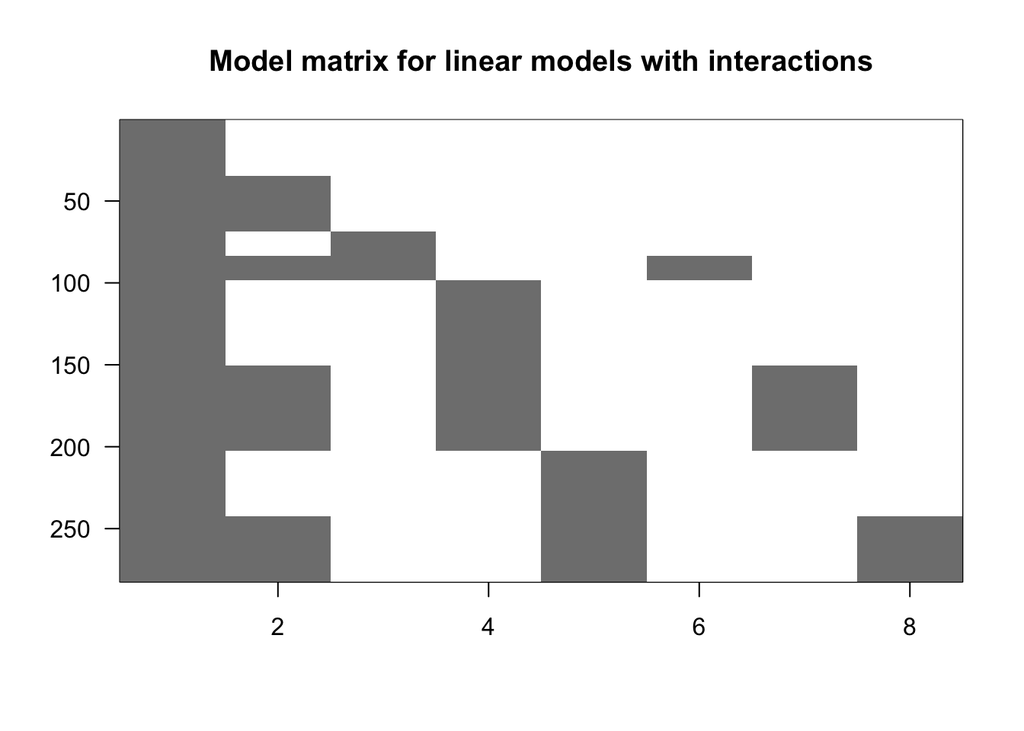

```r
imagemat(X, main = "Model matrix for linear models with interactions")
```

Fit the new X model matrix to linear model lm() to reflect typepush of each leg pair:

```r
fit3 <- lm(friction ~ type*leg, data = spider)
summary(fit3)
```

```
Call:
lm(formula = friction ~ type * leg, data = spider)

Residuals:
     Min       1Q   Median       3Q      Max
-0.46385 -0.10735 -0.01111  0.07848  0.76853

Coefficients:
               Estimate Std. Error t value Pr(>|t|)
(Intercept)     0.92147    0.03266  28.215  < 2e-16 ***
typepush       -0.51412    0.04619 -11.131  < 2e-16 ***
legL2           0.22386    0.05903   3.792 0.000184 ***
legL3           0.35238    0.04200   8.390 2.62e-15 ***
legL4           0.47928    0.04442  10.789  < 2e-16 ***
typepush:legL2 -0.10388    0.08348  -1.244 0.214409
typepush:legL3 -0.38377    0.05940  -6.461 4.73e-10 ***
typepush:legL4 -0.39588    0.06282  -6.302 1.17e-09 ***
---
Signif. codes:  0 '***' 0.001 '**' 0.01 '*' 0.05 '.' 0.1 ' ' 1

Residual standard error: 0.1904 on 274 degrees of freedom
Multiple R-squared:  0.8279,    Adjusted R-squared:  0.8235
F-statistic: 188.3 on 7 and 274 DF,  p-value: < 2.2e-16
```

```r
coefs <- coef(fit3)
```

P values compare significance between L2 typepush vs L1 typepush (reference).Ltypepush:legL2 has p > 0.05. However, typepush:legL3 vs L1 typepush has significant p < 0.05.

```r
library(contrast)
L3vsL2 <- contrast(fit2, list(leg = "L3", type = "pull"), list(leg = "L2", type = "pull"))
L3vsL2
```

```
lm model parameter contrast

    Contrast       S.E.      Lower      Upper     t  df Pr(>|t|)
 -0.01142949 0.04319685 -0.0964653 0.07360632 -0.26 277   0.7915
```

```r
# or, equivalent to (produces same value as contrast():
coefL3vsL2 <- coef[3] - coef[2]
coefL3vsL2
```

```
      legL3
-0.01142949
```

To compare push vs pull coefficients for same leg pair (L2):

```r
L2push.vs.pull <- contrast(fit3,
                           list(leg = "L2", type = "push"), list(leg = "L2", type = "pull"))
L2push.vs.pull
```

```
lm model parameter contrast

 Contrast      S.E.      Lower      Upper     t  df Pr(>|t|)
   -0.618 0.0695372 -0.7548951 -0.4811049 -8.89 274        0
```

```r
C <- L2push.vs.pull$X # open matrix
C
```

```
  (Intercept) typepush legL2 legL3 legL4 typepush:legL2 typepush:legL3
1           0        1     0     0     0              1              0
  typepush:legL4
1              0
attr(,"assign")
[1] 0 1 2 2 2 3 3 3
attr(,"contrasts")
attr(,"contrasts")$type
[1] "contr.treatment"

attr(,"contrasts")$leg
[1] "contr.treatment"
```

```r
# above contrast() is also equivalent to:
coefs[2] + coefs[6]
```

```
typepush
  -0.618
```

==> typepush = -0.618,

i.e. typepush for L2 is 0.618 less in friction coefficient than L2 typepull

## Contrasts: difference of differences

Above compares between 2 variables: type (push or pull) for a leg pair (L1-L4), vs another type(push or pull) for a leg pair (L1-L4). e.g. L2 typepush vs L1 typepush.

It is difficult to compare differences between leg pairs using the p-values from fit3, as these are based on comparison between that respective leg pair **against baseline (L1)**.

To compare difference of differences, use ANOVA: analysis of variance: analyse general variance in push *and* pull against other leg pairs. What is the likelihood that the differences in typepull and typepush across all leg pairs (L1-L4) are due to chance?

```r
anova(fit3) # produces F-test: testing 3 coefficients at once (df)
```

```
Analysis of Variance Table

Response: friction
           Df Sum Sq Mean Sq  F value    Pr(>F)
type        1 42.783  42.783 1179.713 < 2.2e-16 ***
leg         3  2.921   0.974   26.847 2.972e-15 ***
type:leg    3  2.098   0.699   19.282 2.256e-11 ***
Residuals 274  9.937   0.036
---
Signif. codes:  0 '***' 0.001 '**' 0.01 '*' 0.05 '.' 0.1 ' ' 1
```

type < 0.05, significant p-value (also based on F-value): i.e. there is a significant difference between typepush and typepull across all leg pairs.

i.e. spiders have significantly higher friction for pulling movement vs pushing movement.